# Veille TECHNOLOGIQUE Pyplot

# Tracé avec des chaînes de mots-clés

Il y a des cas où vous avez des données dans un format qui vous permet accéder à des variables particulières avec des chaînes. Par exemple, avec `numpy.recarray` ou `pandas.DataFrame`.

Matplotlib vous permet de fournir un tel objet avec l'argument du mot clé `data`. Si fourni, vous pouvez générer des graphiques avec les chaînes correspondant à ces variables.

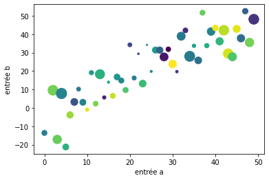

```python
data = {'a': np.arange(50),
        'c': np.random.randint(0, 50, 50),
        'd': np.random.randn(50)}
data['b'] = data['a'] + 10 * np.random.randn(50)
data['d'] = np.abs(data['d']) * 100

plt.scatter('a', 'b', c='c', s='d', data=data)
plt.xlabel('entrée a')
plt.ylabel('entrée b')
plt.show()
```

# Tracé avec des variables catégorielles

Il est également possible de créer un graphique à l'aide de variables catégorielles. Matplotlib vous permet de passer directement des variables catégorielles à de nombreuses fonctions de tracé. Par example:

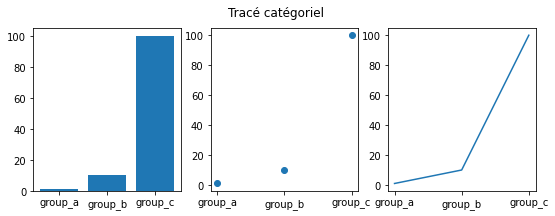

```python
names = ['group_a', 'group_b', 'group_c']
values = [1, 10, 100]

plt.figure(figsize=(9, 3))

plt.subplot(131)
plt.bar(names, values)
plt.subplot(132)
plt.scatter(names, values)
plt.subplot(133)
plt.plot(names, values)
plt.suptitle('Tracé catégoriel')
plt.show()
```

# Contrôler les propriétés de la ligne

Les lignes ont de nombreux attributs que vous pouvez définir : largeur de ligne, style de tiret, anticrénelé, etc. voir `matplotlib.lines.Line2D`. Il y a plusieurs façons de définir les propriétés de la ligne

- Utilisez des arguments de mots clés : :

  ```
  plt.plot(x, y, largeur de ligne=2.0)
  ```

- Utiliser les méthodes setter d'une instance `Line2D`. `plot` renvoie une liste d'objets `Line2D` ; par exemple, `ligne1, ligne2 = plot(x1, y1, x2, y2)`. Dans le code ci-dessous, nous supposerons que nous n'avons que une ligne pour que la liste renvoyée soit de longueur 1. Nous utilisons le déballage des tuples avec `line,` pour obtenir le premier élément de cette liste : :

  ```
  ligne, = plt.plot(x, y, '-')
  line.set_antialiased(False) # désactiver l'anticrénelage
  ```

- Utilisez `~.pyplot.setp`. L'exemple ci-dessous utilise une fonction de style MATLAB pour définir plusieurs propriétés sur une liste de lignes. `setp` fonctionne de manière transparente avec une liste d'objets ou un seul objet. Vous pouvez soit utiliser des arguments de mot-clé python ou Paires chaîne/valeur de style MATLAB : :

  ```
  lignes = plt.plot(x1, y1, x2, y2)
  # utiliser des arguments de mot-clé
  plt.setp(lignes, couleur='r', largeur de ligne=2.0)
  # ou paires de valeurs de chaîne de style MATLAB
  plt.setp(lignes, 'couleur', 'r', 'largeur de ligne', 2.0)
  ```

Voici les propriétés `~.lines.Line2D` disponibles.

| Property | Value Type |
| --- | --- |
| alpha | float |
| animated | [True \| False] |
| antialiased or aa | [True \| False] |
| clip_box | a matplotlib.transform.Bbox instance |
| clip_on | [True \| False] |
| clip_path | a Path instance and a Transform instance, a Patch |
| color or c | any matplotlib color |
| contains | the hit testing function |
| dash_capstyle | ['butt' \| 'round' \| 'projecting'] |
| dash_joinstyle | ['miter' \| 'round' \| 'bevel'] |
| dashes | sequence of on/off ink in points |
| data | (np.array xdata, np.array ydata) |
| figure | a matplotlib.figure.Figure instance |
| label | any string |
| linestyle or ls | [ '-' \| '--' \| '-.' \| ':' \| 'steps' \| ...] |
| linewidth or lw | float value in points |
| marker | [ '+' \| ',' \| '.' \| '1' \| '2' \| '3' \| '4' ] |
| markeredgecolor or mec | any matplotlib color |
| markeredgewidth or mew | float value in points |
| markerfacecolor or mfc | any matplotlib color |
| markersize or ms | float |
| markevery | [ None \| integer \| (startind, stride) ] |
| picker | used in interactive line selection |
| pickradius | the line pick selection radius |
| solid_capstyle | ['butt' \| 'round' \| 'projecting'] |
| solid_joinstyle | ['miter' \| 'round' \| 'bevel'] |
| transform | a matplotlib.transforms.Transform instance |
| visible | [True \| False] |
| xdata | np.array |
| ydata | np.array |
| zorder | any number |

Pour obtenir une liste des propriétés de ligne réglables, appelez le Fonction `~.pyplot.setp` avec une ou plusieurs lignes en argument

```
in [69] : lignes = plt.plot([1, 2, 3])

    in [70] : plt.setp(lignes)
      alpha : float
      animated : [True | False]
      antialiased ou aa : [True | False]
      ...snip
```

# Travailler avec plusieurs figures et axes

MATLAB et `.pyplot`, ont le concept de la figure actuelle et les axes actuels. Toutes les fonctions de traçage s'appliquent au courant haches. La fonction `~.pyplot.gca` renvoie les axes courants (un instance `matplotlib.axes.Axes`), et `~.pyplot.gcf` renvoie l'instance actuelle figure (une instance `matplotlib.figure.Figure`). Normalement, vous n'avez pas à s'inquiéter à ce sujet, parce que tout est pris en charge dans les coulisses. Au dessous de est un script pour créer deux intrigues secondaires.

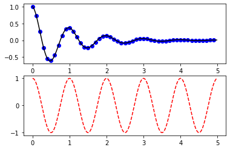

```python
def f(t):
    return np.exp(-t) * np.cos(2*np.pi*t)

t1 = np.arange(0.0, 5.0, 0.1)
t2 = np.arange(0.0, 5.0, 0.02)

plt.figure()
plt.subplot(211)
plt.plot(t1, f(t1), 'bo', t2, f(t2), 'k')

plt.subplot(212)
plt.plot(t2, np.cos(2*np.pi*t2), 'r--')
plt.show()
```

L'appel `~.pyplot.figure` ici est facultatif car une figure sera créée s'il n'en existe pas, tout comme un axe sera créé (équivalent à un `subplot()`) s'il n'en existe pas. L'appel `~.pyplot.subplot` spécifie

```
numrows,
numcols, plot_number
```

où `plot_number` va de 1 à `numrows*numcols`. Les virgules dans l'appel `subplot` sont facultatif si `numrows*numcols<10`. Donc `subplot(211)` est identique à `sous-intrigue(2, 1, 1)`.

Vous pouvez créer un nombre arbitraire de sous-parcelles et haches. Si vous souhaitez placer un axe manuellement, c'est-à-dire pas sur un grille rectangulaire, utilisez `~.pyplot.axes`, qui vous permet de spécifier l'emplacement comme

```
axes([gauche, bas,
largeur, hauteur])
```

où toutes les valeurs sont en fraction (0 à 1) coordonnées. Voir `/gallery/subplots_axes_and_figures/axes_demo` pour un exemple de placer des axes manuellement et `/gallery/subplots_axes_and_figures/subplot_demo` pour un exemple avec beaucoup de sous-parcelles.

Vous pouvez créer plusieurs figures en utilisant plusieurs `~.pyplot.figure` appels avec un chiffre croissant numéro. Bien entendu, chaque figure peut contenir autant d'axes et de sous-parcelles comme ton coeur le désire

```
import matplotlib.pyplot as plt
    plt.figure(1)                # the first figure
    plt.subplot(211)             # the first subplot in the first figure
    plt.plot([1, 2, 3])
    plt.subplot(212)             # the second subplot in the first figure
    plt.plot([4, 5, 6])


    plt.figure(2)                # a second figure
    plt.plot([4, 5, 6])          # creates a subplot() by default

    plt.figure(1)                # figure 1 current; subplot(212) still current
    plt.subplot(211)             # make subplot(211) in figure1 current
    plt.title('Easy as 1, 2, 3') # subplot 211 title
```

Vous pouvez effacer le chiffre actuel avec `~.pyplot.clf` et les axes courants avec `~.pyplot.cla`. Si tu trouves c'est ennuyeux que les états (en particulier l'image actuelle, la figure et les axes) sont entretenus pour vous en coulisses, ne désespérez pas : ce n'est qu'un mince wrapper avec état autour d'une API orientée objet, que vous pouvez utiliser à la place (voir `/tutorials/intermediate/artists`)

Si vous faites beaucoup de chiffres, vous devez en connaître un plus de chose : la mémoire nécessaire pour une figure n'est pas complètement libéré jusqu'à ce que la figure soit explicitement fermée avec `~.pyplot.close`. Supprimer toutes les références au figure, et/ou en utilisant le gestionnaire de fenêtres pour tuer la fenêtre dans laquelle le chiffre apparaît à l'écran, ne suffit pas, car pyplot maintient les références internes jusqu'à `~.pyplot.close` est appelé.

# Travailler avec du texte

`~.pyplot.text` peut être utilisé pour ajouter du texte dans un emplacement arbitraire, et `~.pyplot.xlabel`, `~.pyplot.ylabel` et `~.pyplot.title` sont utilisés pour ajouter texte aux emplacements indiqués (voir `/tutorials/text/text_intro` pour un exemple plus détaillé)

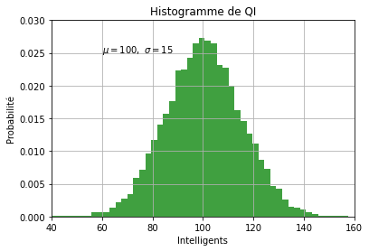

```python
mu, sigma = 100, 15
x = mu + sigma * np.random.randn(10000)

# l' histogramme de données
n, bins, patches = plt.hist(x, 50, density=1, facecolor='g', alpha=0.75)


plt.xlabel('Intelligents')
plt.ylabel('Probabilité')
plt.title('Histogramme de QI')
plt.text(60, .025, r'$\mu=100,\ \sigma=15$')
plt.axis([40, 160, 0, 0.03])
plt.grid(True)
plt.show()
```

Toutes les fonctions `~.pyplot.text` renvoient un `matplotlib.text.Text` exemple. Tout comme pour les lignes ci-dessus, vous pouvez personnaliser les propriétés en en passant des arguments de mot-clé dans les fonctions de texte ou en utilisant `~.pyplot.setp` ::

t = plt.xlabel('mes données', taille de police=14, couleur='rouge')

Ces propriétés sont décrites plus en détail dans `/tutorials/text/text_props`.

## Utiliser des expressions mathématiques dans le texte

matplotlib accepte les expressions d'équation TeX dans n'importe quelle expression de texte. Par exemple pour écrire l'expression $\sigma_i=15$ dans le titre, vous pouvez écrire une expression TeX entourée de signes dollar : :

```
plt.title(r'$\sigma_i=15$')
```

Le `r` précédant la chaîne du titre est important -- il signifie que la chaîne est une chaîne *brute* et de ne pas traiter les barres obliques inverses comme python s'échappe. matplotlib a un analyseur d'expression TeX intégré et moteur de mise en page et fournit ses propres polices mathématiques -- pour plus de détails, voir `/tutorials/text/mathtext`. Ainsi, vous pouvez utiliser du texte mathématique sur toutes les plateformes sans nécessiter l'installation de TeX. Pour ceux qui ont LaTeX et dvipng installé, vous pouvez également utiliser LaTeX pour formater votre texte et incorporer la sortie directement dans vos chiffres d'affichage ou enregistrés postscript -- voir `/tutorials/text/usetex`.

## Texte d'annotation

Les utilisations de la fonction de base `~.pyplot.text` ci-dessus placer le texte à une position arbitraire sur les axes. Une utilisation courante pour le texte est d'annoter une caractéristique de l'intrigue, et le La méthode `~.pyplot.annotate` fournit une aide fonctionnalité pour faciliter les annotations. Dans une annotation, il y a deux points à considérer : l'emplacement étant annoté représenté par l'argument `xy` et l'emplacement du texte `xytext`. Les deux ces arguments sont des tuples `(x, y)`.

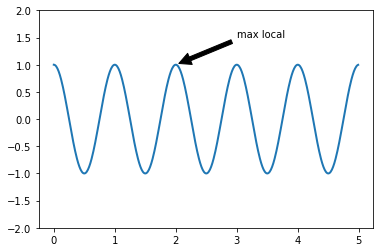

```python
ax = plt.subplot()

t = np.arange(0.0, 5.0, 0.01)
s = np.cos(2*np.pi*t)
line, = plt.plot(t, s, lw=2)

plt.annotate('max local', xy=(2, 1), xytext=(3, 1.5),
             arrowprops=dict(facecolor='black', shrink=0.05),
             )

plt.ylim(-2, 2)
plt.show()
```

Dans cet exemple de base, le `xy` (pointe de flèche) et le `xytext` les emplacements (emplacement du texte) sont en coordonnées de données. Il y a un variété d'autres systèmes de coordonnées que l'on peut choisir -- voir `annotations-tutorial` et `plotting-guide-annotation` pour des détails. Vous trouverez d'autres exemples dans :doc:`/gallery/text_labels_and_annotations/annotation_demo`.

# Axes logarithmiques et autres axes non linéaires

:mod:`matplotlib.pyplot` prend en charge non seulement les échelles d'axe linéaire, mais aussi échelles logarithmique et logit. Ceci est couramment utilisé si les données s'étendent sur de nombreuses commandes de grandeur. Changer l'échelle d'un axe est simple :

```
plt.xscale('log')
```

Un exemple de quatre tracés avec les mêmes données et des échelles différentes pour l'axe des y est montré ci-dessous.

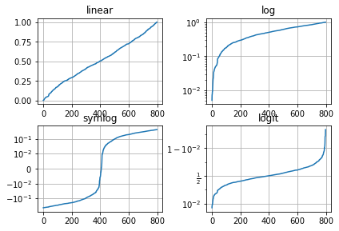

```python
# Correction de l'état aléatoire pour la reproductibilité
np.random.seed(19680801)

# composer des données dans l'intervalle ouvert (0, 1)
y = np.random.normal(loc=0.5, scale=0.4, size=1000)
y = y[(y > 0) & (y < 1)]
y.sort()
x = np.arange(len(y))

# tracé avec différentes échelles d'axes
plt.figure()

# lineaire
plt.subplot(221)
plt.plot(x, y)
plt.yscale('linear')
plt.title('linear')
plt.grid(True)

# log
plt.subplot(222)
plt.plot(x, y)
plt.yscale('log')
plt.title('log')
plt.grid(True)

# symmetric log
plt.subplot(223)
plt.plot(x, y - y.mean())
plt.yscale('symlog', linthresh=0.01)
plt.title('symlog')
plt.grid(True)

# logit
plt.subplot(224)
plt.plot(x, y)
plt.yscale('logit')
plt.title('logit')
plt.grid(True)

# Ajustez la disposition de la sous-intrigue, car la logit peut prendre plus de place
# que d'habitude, en raison des étiquettes y-tick comme "1 - 10^{-3}"
plt.subplots_adjust(top=0.92, bottom=0.08, left=0.10, right=0.95, hspace=0.25,
                    wspace=0.35)

plt.show()
```

Il est également possible d'ajouter votre propre échelle, voir `adding-new-scales` pour des détails.